# 21.11. Геометрические годографы центра сердца и камерной крови на трёх исторических 4D-КТ

**Исследовательский результат.** Рассчитаны геометрические центры автоматических масок 20 реконструированных фаз одной исторической контрастной КТ (обезличенная серия `historical_01 / sequence_02`). Это подробный разбор первой серии; ниже к нему добавлены ещё две серии, обработанные тем же методом, а не реконструкция электрического центра и не уже выполненное парное сопоставление с конкретным добровольцем РФФИ. Сопоставление личности и сессии между источниками не подтверждено.

Использованы уже рассчитанные маски **TotalSegmentator v2**: `total/heart` для целого сердца и объединение четырёх `heartchambers_highres` камер для крови, без аорты и лёгочной артерии. Их не пересегментировали. Источники — фазовый манифест и зафиксированный список контрольных сумм масок; программа сверила хэши, форму, аффинное преобразование, единицы и число фаз. В каждом объёме центром считается среднее физических координат всех включённых вокселей: $\mathbf c=|M|^{-1}\sum_{\mathbf i\in M} A(\mathbf i,1)$, где $A$ — преобразование индекса в RAS-миллиметры. Это **геометрический центр маски**, не центр масс тканей с различной плотностью. Смещения отсчитываются от фазы 0% своей серии. Исходные КТ и маски остаются вне Git.

По предыдущему отчёту 21.10 автоматические маски допустимы как рабочий исследовательский вход: были проверены пофазные сетки и расчёт объёмов, выполнен ограниченный анатомический просмотр. Сравнение двух фаз с кандидатной разметкой не задаёт независимо доказанную малую погрешность положения **центра** на всех 20 фазах. Поэтому эти кривые показывают поведение выбранной сегментации; точность геометрического годографа относительно истинного движения ещё предстоит оценить.

**Правило осей.** В NIfTI RAS+ $+x$ направлена вправо, $+y$ кпереди, $+z$ к голове. На схеме рис. 25 отчёта РФФИ ось $x$ направлена вправо по рисунку, $y$ — вверх, $z$ показана в перспективе вне XY. При принятой фронтальной интерпретации схемы XY РФФИ — фронтальная плоскость, а XY КТ — поперечная. Поэтому для сопоставления **типа плоскости** строим $(\Delta x_{RAS},\Delta z_{RAS})$. Однако отчёт не фиксирует однозначно, соответствует ли $+x$ РФФИ правой или левой стороне пациента. Отражение по поперечной оси остаётся возможным до регистрации по независимым ориентирам. Полное согласование координат не выполнено; совпадают только выбранный тип плоскости и миллиметровые единицы, но не доказаны знак поперечной оси, начало и регистрация исследований.

## Рисунок 1. Плоские годографы по 20 фазам

Слева вверху показан центр всей сердечной маски; справа вверху — центр объединённых полостей крови. Это две разные цели аппроксимации. Нижние панели показывают поперечную и сагиттальную проекции центра крови. Квадрат обозначает исходные 0%, цвет — фазу реконструкции, линии соединяют дискретные точки без сглаживания. Последняя доступная фаза 95% не соединяется искусственно с первой. Равный масштаб осей позволяет видеть форму и амплитуду смещения в миллиметрах. Подписи 25, 50 и 75% помогают проследить порядок движения, а не автоматически подтверждённые моменты клапанных событий.

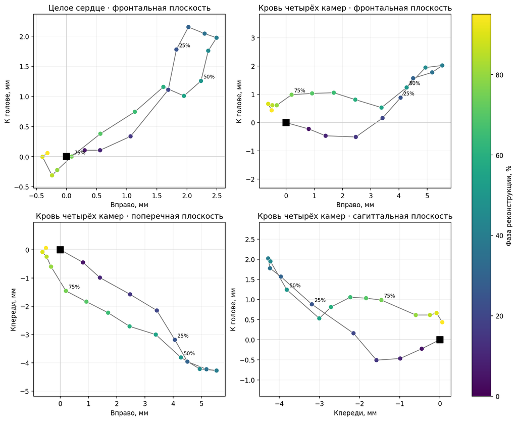

Размах координат центра целого сердца: **2.90 мм вправо–влево, 2.38 мм кпереди–кзади, 2.46 мм к голове–ногам**. Для объединённой крови камер — **6.17, 4.33 и 2.53 мм** соответственно. Наибольшее расстояние от положения при 0% достигает **3.96 мм** для всего сердца и **7.28 мм** для крови; в обеих масках оно приходится на фазу **40%**. Больший размах кровяной кривой нельзя считать доказательством большей физической подвижности крови: на него влияют как движение камер, так и изменение их формы, долей и границ масок.

## Рисунок 2. Компоненты траекторий и объёмы

На верхних и левой нижней панелях показаны подписанные координатные смещения относительно 0%. Правая нижняя панель показывает объёмы тех же масок. Параллельное изменение объёма и положения центра не означает причинной связи между ними: центр может смещаться при неизменном объёме и наоборот. Отдельное сравнение координат и размеров эквивалентной модели требует физической прямой задачи.

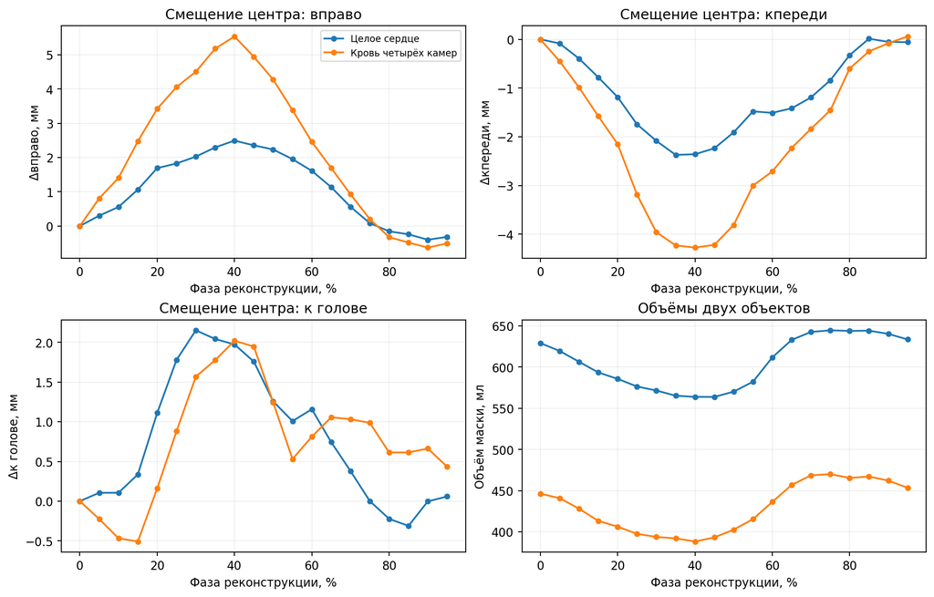

Размах автоматического объёма равен **80.9 мл** для всего сердца и **81.8 мл** для объединённых камер. Эти числа не следует трактовать как ударный объём: маска крови включает предсердия и оба желудочка, а фазовые и анатомические границы ещё не подтверждены независимым референсом.

**Контроль геометрии.** Ни одна из этих двух масок не касается крайних граней реконструированного объёма на 20 фазах; это не исключает неверной внутренней границы. Маски отдельных камер между собой не перекрываются. При этом две задачи TotalSegmentator не вложены идеально: максимальная часть объединённых камер вне `total/heart` составляет **11.63 мл** (около **3.0%** объёма крови в фазе максимального расхождения). Поэтому при расчёте кровяного центра использовано прямое объединение четырёх камер, без искусственного отсечения по маске целого сердца.

## Рисунок 3. Исходные годографы РФФИ и границы сравнения

Ниже воспроизведены фрагменты XY из рис. 27, 29 и 31 отчёта РФФИ 2021. Они показывают **электрически восстановленный центр эквивалентной сферы крови**, сглаженный по 25 интервалам цикла. Наши кривые показывают непосредственные геометрические центры автоматических масок в 20 КТ-фазах. Следовательно, наиболее близок по анатомической области наш центр объединённой крови камер, но и он не равен центру эквивалентной сферы. Фрагменты не оцифрованы, пары участников и фаз не установлены. Ни сходство, ни различие очертаний здесь не является количественной ошибкой электрического метода.

Источник: «Отчет РФФИ 2021 v2.1.pdf», разд. 5.3, рис. 25, 27, 29, 31; происхождение и хэш фрагментов сохранены в отчёте 40.23.

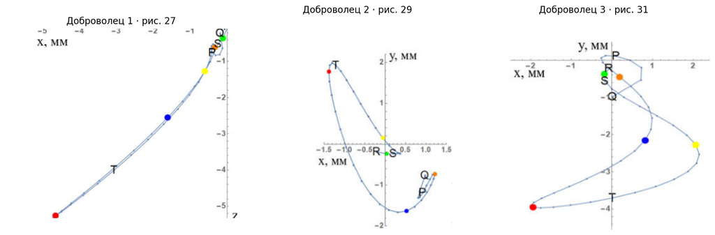

## Числовые данные и воспроизведение

В таблице приведены фронтальные смещения по всем доступным фазам. Знак соответствует RAS+: положительный $x$ направлен вправо, положительный $z$ — к голове. Это исходные оценки без сглаживания. Дополнительная глубинная компонента $y$ содержится в локальном расчётном JSON и на рисунке 2.

| Фаза, % | Целое сердце: Δx, мм | Целое сердце: Δz, мм | Кровь камер: Δx, мм | Кровь камер: Δz, мм |
| --- | --- | --- | --- | --- |
| 0 | 0.00 | 0.00 | 0.00 | 0.00 |
| 5 | 0.30 | 0.11 | 0.81 | -0.22 |
| 10 | 0.56 | 0.11 | 1.41 | -0.47 |
| 15 | 1.06 | 0.34 | 2.47 | -0.51 |
| 20 | 1.69 | 1.11 | 3.42 | 0.16 |
| 25 | 1.83 | 1.78 | 4.06 | 0.88 |
| 30 | 2.03 | 2.15 | 4.50 | 1.57 |
| 35 | 2.30 | 2.04 | 5.18 | 1.78 |
| 40 | 2.49 | 1.97 | 5.54 | 2.02 |
| 45 | 2.36 | 1.76 | 4.94 | 1.95 |
| 50 | 2.23 | 1.26 | 4.28 | 1.24 |
| 55 | 1.95 | 1.01 | 3.38 | 0.53 |
| 60 | 1.61 | 1.16 | 2.46 | 0.81 |
| 65 | 1.14 | 0.74 | 1.70 | 1.06 |
| 70 | 0.56 | 0.38 | 0.93 | 1.03 |
| 75 | 0.08 | 0.00 | 0.20 | 0.99 |
| 80 | -0.16 | -0.22 | -0.33 | 0.61 |
| 85 | -0.24 | -0.31 | -0.48 | 0.61 |
| 90 | -0.40 | -0.00 | -0.63 | 0.66 |
| 95 | -0.32 | 0.06 | -0.51 | 0.43 |

Расчётный код: `build_old_ct_hodographs.py`. Его входы — локальная папка NIfTI-фаз `sequence_02/phases` и завершённый каталог масок `sequence02_ts_comparator_v1`; результат записывается в новый каталог `results/old_hodographs_20260925/historical_01_sequence_02`. Абсолютные пути к КТ задаются при запуске, в ноутбук не встроены. Фазовые проценты поступают из локального манифеста реконструкции; он не устанавливает часы сердечного цикла в секундах или момент R-зубца. Ниже та же программа применена к двум дополнительным полным последовательностям после их сегментации TotalSegmentator и проверки происхождения масок.

**Следующий проверочный шаг:** установить документальную связь серий КТ с добровольцами отчёта РФФИ, уточнить выбор соответствующих реконструкций, проверить независимыми анатомическими ориентирами систему координат и фазовую привязку. Лишь после этого допустимо количественное сравнение геометрического центра крови с электрически восстановленным центром сферы.

## Сопоставление трёх архивных серий

После первой серии тем же преобразователем Enhanced CT и той же версией TotalSegmentator обработаны ещё две независимые исторические серии. Для каждой предварительно выбрана одна полная последовательность из 20 фаз, 0–95% с шагом 5%. В двух новых сериях использована реконструкция `sequence_11`; выбор сделан по полноте временного ряда, анатомическая пригодность поля обзора требует дальнейшего экспертного просмотра. Для каждой фазы проверены хэш исходной КТ, система RAS+, совпадение сетки масок с КТ, контрольные суммы результатов сегментации и непустота масок. Все три серии различаются между собой и не объединялись по фазам.

**Рисунок 4.** Фронтальные траектории центров целого сердца (верхний ряд) и объединённых камер крови (нижний ряд). Во всех шести панелях одинаковые физические пределы и масштаб осей; квадрат обозначает 0%, цвет — 0–95%. Это позволяет сравнить амплитуду и форму без независимого автомасштабирования каждого графика. Серии обозначены А, Б и В (локальные коды `historical_01`, `historical_02`, `historical_03` соответственно); они не означают «доброволец 1–3» из отчёта РФФИ. Нельзя сопоставлять панели РФФИ и КТ по порядковому номеру.

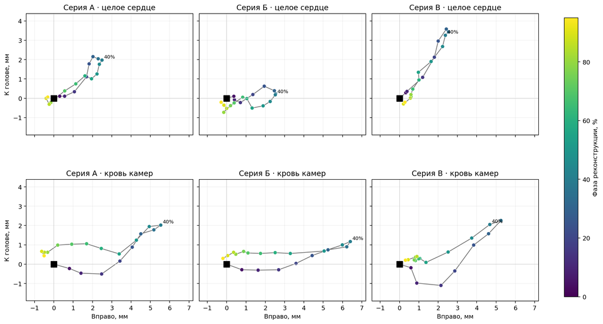

Во всех трёх сериях размах поперечного смещения геометрического центра объединённых камер крови больше, чем у маски целого сердца. Это устойчивая **особенность этих автоматических масок**, а не доказательство универсального физиологического закона. Вертикальная амплитуда между сериями заметно различается. Совпадение порядков величин с миллиметровой шкалой РФФИ не позволяет оценить ошибку электрического метода, поскольку соответствие участников не установлено и цели определения центра различаются.

| Серия | Целое сердце: размах вправо, мм | Кровь камер: размах вправо, мм | Кровь камер: размах к голове, мм | Наибольшее расстояние центра крови от 0%, мм |
| --- | --- | --- | --- | --- |
| А (`historical_01`) | 2.90 | 6.17 | 2.53 | 7.28 |
| Б (`historical_02`) | 2.82 | 6.60 | 1.48 | 7.03 |
| В (`historical_03`) | 2.54 | 5.26 | 3.36 | 6.44 |

Ни одна из масок целого сердца или объединённых камер не касается границы реконструированного объёма в этих 60 фазах, однако отсутствие касания не доказывает полноту анатомии. Задачи `total/heart` и `heartchambers_highres` сегментируют объекты независимо, поэтому часть камер может оказаться вне маски целого сердца. Небольшая ошибка объёма также не ограничивает автоматически ошибку центра: если на противоположных сторонах маски один участок пропущен, а другой добавлен, общий объём может почти не измениться, тогда как центр сместится. Независимой ручной пофазной оценки **точности центров** для этих трёх серий нет.

Для прямого сравнения с РФФИ теперь необходимы: документальное соответствие конкретных людей и сессий; согласование физического определения крови; регистрация систем координат по анатомическим ориентирам; независимая фазовая привязка к R-зубцу; и оценка неопределённости геометрической и электрической траекторий. До этого рисунки представляют проверку гипотезы о форме и масштабе движения центров, а не валидацию электрического годографа.